# Land Steward Report

Avalon Cook

September 23 2025

# Joseph Phelps Vineyards - Borgo Plot Soil carbon amendments, Cover crops, and Livestock integration

## Background: ACTION for CSA and Ag-C

Thank you for participating in the Agricultural Carbon Monitoring Program. Ag-C was developed to help practitioners conduct transparent, fit-for-purpose monitoring of aboveground and belowground carbon in response to common conservation practices. At the same time that it supports management efforts at the farm scale, Ag-C is designed to evaluate management effects on carbon at regional scales when data is aggregated network-wide in the secure Point Blue Science Cloud. The collected information, from management history to field measurements, will support greater understanding of commonly incentivized practice impact on ecosystem carbon.

The Agricultural Carbon (“Ag-C”) Monitoring Program was developed by the Soils Team at Point Blue Conservation Science to help practitioners conduct transparent, fit-for-purpose monitoring of carbon dynamics in response to rangeland and cropland management. This report reviews the initial measurement for the baseline carbon indicators measured at your agricultural site. Continued use of the Ag-C protocols over time can assess the impact of your conservation effort.

This report reviews monitoring efforts to date for the carbon indicators measured at your agricultural site. Continued use of the Ag-C protocols over time can assess the long-term impact of your conservation effort. Find additional information and funding updates for continued use of the Ag-C Monitoring Program on [our landing page](https://www.pointblue.org/ag-c/).

## Project Design

The Ag-C program offers a flexible approach to designing a monitoring program. This includes the option to select carbon indicators of interest, tailor methods to your goals and resources, and match project design elements to your context. Ag-C is made of two major components: Range-C to accommodate monitoring in rangeland systems and Crop-C to accommodate monitoring in cropland systems. At your site, Crop-C was used as the guiding framework for developing a monitoring plan.[^1]

To support interpretability and comparability, Crop-C assigns each monitoring project an “inference score” which reflects how decisions made in the project design process impact the overall rigor and reliability of the resulting data. Inference scores range from 40 to 100, where a higher score generally reflects greater confidence in the project’s findings or a more holistic characterization of carbon dynamics in the study site. Nonetheless, all Crop-C projects represent a minimum standard of rigor and reliability.

### Carbon indicators

The following table includes carbon indicators that were included in this monitoring project and their corresponding acronyms that will be used in the following tables, graphs, and maps. A description of each indicator and reported units are provided.

Table 1: Description of carbon indicators

[output not shown]

### Spatial design

The interactive map below shows the boundaries of the study area for monitoring and how sampling points are distributed.

[interactive chart not shown]

The following indicators were measured at every sampling point: Soil Organic Carbon, Soil Bulk Density  
The following indicators were measured at JPBO.04 and JPBO.06: Soil Texture, Soil pH, Cation Exchange Capacity, CO2 Respiration, Nitrate, Phosphorus, Potassium, Sulfur, Calcium, Magnesium, Sodium, Zinc, Iron, Manganese, and Copper  
Sampling points were randomly selected within the monitoring boundary using mapping software and located in the field by GPS.

### Other design elements

The Ag-C framework flexibly accommodates different project design approaches. For example, the most rigorous project would include baseline monitoring before the conservation practice is implemented, as well as parallel monitoring at an untreated control site into the future. Although not logistically possible for every project, these elements together provide highly interpretable results.

This Crop-C project did not capture baseline conditions before practice implementation and was not able to compare current conditions to an untreated control site. While we are still able to characterize current conditions now and into the future, the results will have limited interpretability for understanding the full scope of practice impact.  
Soil samples were taken to a target maximum depth of 12 inches.

## Results

### All soil properties

The following table summarizes average values across the study area for all soil metric(s) included in your project.

Table 2: Soil Metrics

| Indicator | Unit | Treatment |
| --- | --- | --- |
| SOC | % | 1.56 |
| BD | g/cm3 | 1.16 |
| Clay | % | 27.00 |
| pH | NA | 7.55 |
| CEC | meq/100g | 15.30 |
| CO2 Resp | ppm | 76.00 |
| NO3 | ppm | 3.25 |
| P | ppm | 14.75 |
| K | ppm | 269.50 |
| S | ppm | 9.35 |
| Ca | ppm | 2432.00 |
| Mg | ppm | 206.00 |
| Na | ppm | 169.00 |
| Zn | ppm | 5.43 |
| Fe | ppm | 5.25 |
| Mn | ppm | 6.80 |
| Cu | ppm | 12.83 |
| Sand | % | 46.00 |
| Silt | % | 27.00 |

### Texture and organic carbon

The graphic below represents where each soil sample falls in a texture triangle, indicating the percentage of clay-sized, silt-sized, and sand-sized particles. The corresponding USDA texture categories are named inside the triangle. In general, we expect clays to store more SOC than sands. To visualize and explore this effect, the size and color of each point represents the relative SOC % for that soil sample. Darker and larger points represent more SOC content, while smaller and lighter points represent less SOC content.

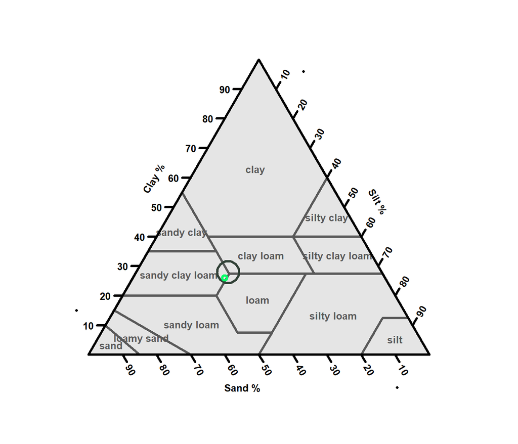

Figure 1: Texture triangle(s) showing texture classifications for samples in the study area. The size and color of bubbles on the plot represent percent soil organic carbon content for each sample, where larger and darker bubbles correspond to higher percentages.

### Soil carbon stocks

The following graph shows calculated carbon stocks values for the study area. Carbon stocks represent the amount of carbon stored in the study area to the specified sampling depth. These ‘violin plots’ also show the variability of carbon stocks across the site. The widest part of the plot represents the most common carbon level in the study area. The white dot represents the average value, and white lines show one standard deviation above and below the average.

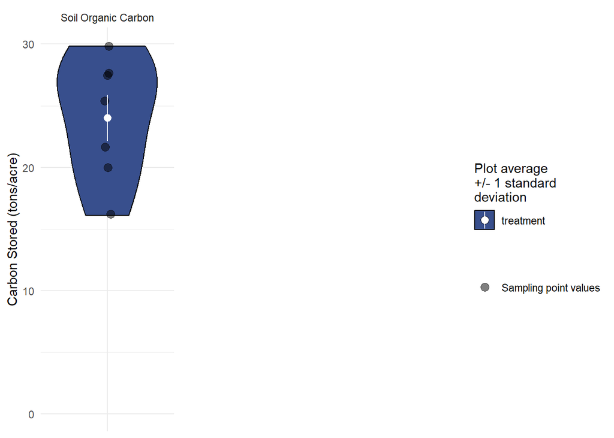

Figure 2: Carbon stocks variability and average

### Dynamic map: all measured values

Use the map below to explore all measured values for each sampling location. Select a layer to visually explore values for a given indicator. Click a point to see all measured values at that point.

[interactive chart not shown]

## Frequently Asked Questions

#### Why is monitoring soil organic carbon important?

Soil organic carbon makes up the majority of soil organic matter which provides a variety of services in agro-ecosystems. Soil organic carbon benefits soil organisms by creating a structured, porous environment. In turn, these soil organisms then increase fertility by cycling nutrients from waste materials, leading to higher productivity. Soils with higher levels of organic carbon have higher water holding capacity contributing to overall landscape resilience. Understanding how soil organic carbon changes in response to management practices across a variety of soils and climates, will help us prioritize lands for maximum conservation planting impact.

#### How can I interpret 1 ton of carbon per acre?

One ton of carbon per acre is equal to 3.67 metric tons of CO2 removed from the atmosphere, equivalent to 1 year of passenger car emissions. It is important to note that 1 ton of carbon per acre in our soil data is only to a 12 inch depth; much more carbon can be stored below that depth.

#### As a land steward, how do I use all of this information?

The information in this report provides a baseline to measure the impact of future management changes. As time series data is not currently available, comparing across different areas of your own farm or ranch is most informative. Explore the dynamic map to gauge how different sites across the study area differ in key metrics. Additionally, our team is working towards a reporting structure that will allow landowners to compare their Ag-C data to other sites within the network, especially to other enrolled farms and ranches in their region. As our database grows, network-wide and regional comparisons will provide an increasingly detailed understanding of differing practice impacts across spatial scales. An online user dashboard allowing Ag-C land stewards to view and compare their results is planned for launch in Fall of 2025.

## Conclusion

Thank you again for your participation in the Ag-C Monitoring Program funded by the USDA ACTION for Climate-Smart Agriculture project. For more information about project design, further interpretation of results, or to access the raw data from your study site, please reach out to RangeC@pointblue.org or CropC@pointblue.org. Our team is happy to engage with additional questions or feedback. Your participation with the Ag-C Monitoring Program and sharing data will launch new scientific understanding of conservation management and support improved incentive structures across the nation.

[^1]: To learn more about designing a monitoring program with Crop-C, consult the [Crop-C Handbook](https://www.pointblue.org/?sdm_process_download=1&download_id=20943)
[^2]: Consult the [Crop-C Handbook](https://www.pointblue.org/?sdm_process_download=1&download_id=20943) for more information about resampling intervals by conservation practice.